# Przestrzenne bazy danych: porównanie bibliotek `spatstat` oraz `sp`

Aleksandra Dzieniszewska

Eryk Warchulskki

# Wprowadzenie

## Zakres i cel projektu

Niniejszy projekt skupia się na porównaniu ze sobą dwóch biblotek dedykowanych danym przestrzennym w języku R, tj.:

- biblotece `spatstat` (w wersji `1.62-2 Shape-shifting lizard`)
- biblotece `sp` (w wersji `1.3-2`).

W projekcie zostaną porównane ze sobą reprezentacje danych przestrzennych przez obie bibloteki oraz ich zasób możliwości do

- wizualizacji
- przetwarzania
- transformacji układu współrzędnych
- odczytu i zapisu danych.

W ramach przeprowadzonych porównań stosowane będą różne metryki – od tych wyrażalnych liczbowo jak czas wykonania lub zajętość pamięci po subiektywne odczucia użytkownika.

# Reprezentacja danych

## Biblioteka `spatstat`

Bibloteka `spatstat` stanowi zbiór funkcji dedykowanych danym przestrzennym. Dokumentacja bibloteki złożona jest z ponad $1700$ stron, co daje około $850$ różnych funkcji. Po samej liczbie dostępnych metod można dojść do wniosku, że pakiet ten oferuje znacznie więcej, niż konstrukcje, wizualizacje czy zapis/odczyt danych przestrzennych. `Spatstat` wspiera m.in.:

- eksploracyjną analizę danych
- modelowanie (wraz z audytem uzyskanych modeli) oraz wnioskowanie statystyczne
- symulacje dwuwymiarowych procesów stochastycznych (t.zw. pól losowych).

W projekcie te aspekty pakietu nie zostaną omówione, ponieważ pakiet `sp` nie zawiera żadnych metod, które pozwalałyby realizować powyższe zagadnienia.

*Reprezentacja danych* w omawianym pakiecie opiera się na czterech klasach zaimplementowanych w prostym systemie obiektowości języka `R`, tj. w systemie `S3`. System ten opiera się na funkcjach generycznych i przez to różni się od systemów obiektowości spotykanych we współczesnych językach obiektowych lub wspierających obiektowość (`Java` lub `Python`) opartą na t.zw. *message-passing*.

Klasy służące do reprezentacji obiektów przestrzennych w biblotece `spatstat` są następujące:

1. Klasa `ppp`
2. Klasa `owin`
3. Klasa `im`
4. Klasa `psp`

Poniżej zostanie scharakteryzowana każda z klas.

### ppp

Klasa `ppp` reprezentuje jeden z obiektów geometrycznych modelowanych przez system typów bibloteki `spatstat`, tj. zbiór punktów (na płaszczyźnie).

Obiekt `ppp` tworzony jest przez konstruktor `spatstat::ppp()`, który przyjmuje jako parametry koordynaty przestrzenne (`x`, `y`) oraz – opcjonalnie – etykietki przyporządkowane punktom (`marks`). Na obiekty `marks` nałożona jest warunek bycia reprezentantem typu `factor` (typ podstawowy języka `R`, który służy do reprezentacji wielkości kategorycznych). Ponadto, z każdym obiektem `ppp` związane jest *okno*, w którym ten obiekt się znajduje, tj. dwuwymiarowa płaszczyzna. Konstruktor obiektu w przypadku braku specyfikacji okna (obiekt typu `owin` jest omawiany w następnej podsekcji) umieszcza punkty w oknie $[0, 1]^{2}$, a te których koordynaty przestrzenne wykraczają poza domyślny obszar – usuwa.

Z obiektami typu `ppp` związane są następujące funkcje:

- `spatstat::as.ppp()`
- `spatstat::plot.ppp()`
- `spatstat::summary.ppp()`
- `spatstat::scapp()`

Sposób utworzenia i wykonywania pewnych operacji na tym typie prezentuje poniższy listing:

```r
library(magrittr)

points_number = 50

points = points_number %>% spatstat::ppp(x = runif(.), y = runif(.), xrange = c(0, 1), yrange = c(0, 1))

points

points %>% summary()

points %>% plot("Punkty")
```

[output not shown]

### owin

Klasa `owin` reprezentuje jeden z obiektów geometrycznych modelowanych przez system typów bibloteki `spatstat`, tj. dwuwymiarową płaszczyznę.

Obiekt `owin` tworzony jest przez konstruktor `spatstat::owin()` i wyróżnia się trzy podtypy tego obiektu:

- `rectangle` (prostokąt)
- `polygonal` (wielokąt)
- `mask` (macierz z wartościami w zbiorze ${0, 1}$)

Obiekty typu `owin` mogą przyjmować dowolny kształt, być wizualizowane bez naniesionych punktów oraz dostępne są specyficzne dla powierzchni metody jak:

- `spatstat::as.ppp()`
- `spatstat::plot.ppp()`
- `spatstat::summary.ppp()`
- `spatstat::area.owin()`
- `spatstat::aperimeter()`
- `spatstat::adiameter.owin()`
- `spatstat::boundingbox()`

Sposób utworzenia i wykonywania pewnych operacji na tym typie prezentuje poniższy listing:

```r
window = spatstat::owin(xrange = c(0, 3), yrange = c(0, 5))

window %>% spatstat::area()

window %>% plot(main = "Okno")
```

[output not shown]

### im

Klasa `im` reprezentuje dwuwymiarowy obraz złożony z pikseli.

Obiekt `im` tworzony jest przez konstruktor `spatstat::im()`, który przyjmuje jako parametry wejściowe:

- macierz wartości `v` oraz jej wymiarowość `dim`
- szerokość `xrange` oraz długość `yrange` okna, które obejmuje obraz
- szerokość `xstep` oraz długość `ystep` piksela
- wektor koordynatów określających centra pikseli `xcol` oraz `yrow`

Sposób utworzenia obiektu `im` prezentuje poniższy listing:

```r
value_mat = matrix(runif(100), nrow=30, ncol=40)

pixel_image = spatstat::im(value_mat)

pixel_image %>% plot(main = 'Szum bialy')
```

[output not shown]

### psp

Klasa `psp` reprezentuje linię i jest typem pochodnym typu `ppp`. Obiekt `psp` tworzony jest przez konstruktor `spatstat::psp()`.

Sposób utworzenia powyższego typu prezentuje poniższy listing:

```r
segment_line = psp(x0 = runif(1), y0 = runif(1), x1 = runif(1), y1= runif(1), window=owin())

segment_line %>% plot(main="Linia")
```

[output not shown]

## Bibloteka `sp`

Bibloteka `sp` jest pakietem funkcji dedykowanych ściśle pod wizualizacje oraz transformacje danych przestrzennych. Pakiet ten nie wspiera czynności dodatkowych, które można wykonywać na danych przestrzennych jak modelowanie lub przeprowadzenie symulacji.

Oparty jest on na innym systemie klas niż pakiet `spatstat` – na znacznie bardziej złożonym i formalnie ścisłym systemie `S4`.

*Reprezentacja danych* w biblotece `sp` oparta jest na 7 klasach w wersji bez dodatkowych atrybutów numerycznych lub kategorycznych (np. `SpatialPoints`) lub z dodatkowymi atrybutami (np. `SpatialPointsDataFrame`). Ponadto, w proponowanym systemie klas przez `sp` istnieje klasa abstrakcyjna `Spatial`, która zawiera metadane wspólnego dla każdego obiektu geometrycznego tej bibloteki.

Poniżej zostaną omówione wszystkie dostępne klasy w wersji dodatkowych atrybutów z wyłączeniem klasy `SpatialPointsDataFrame`, co wynika z faktu bardzo podobnego sposobu konstruowania obiektów tego rodzaju przy użyciu standardowych konstruktorów.

### Spatial

Klasa abstrakcyjna `Spatial` zawiera następujące metody abstrakcyjne:

- `sp::dimensions()`
- `sp::bbox()`
- `sp::coordinates()`
- `sp::spplot()`
- `sp::dimensions()`

### SpatialPoints

Konstrukcja obiektu `SpatialPoints` odbywa się przy pomocy konstruktura `sp::SpatialPoints()`, który jako parametr wejściowy przyjmuje `coords`, będący macierzą (lub ramką danych `data.frame`) $n$-wymiarową.

W przypadku potrzeby konstrukcji obiektu z dodatkowymi danymi, tj. typów `Spatial_DataFrame`, konstruktor przyjmuje parametr `data`, będący obiektem typu `data.frame` o liczbie wierszy równej `coords`.

W pakiecie istnieje również klasa `SpatialMultiPoint`, która jest rozszerzeniem `SpatialPoints` o możliwość przechowywania koordynatów wielu punktów, tj.

```r
SpatialMultiPoints(list(
                    cbind(rnorm(3, 10), rnorm(3, 10)), # koordynaty 1...
                    cbind(rnorm(5, 10), rnorm(5, 0)) # koordynaty 2...
                    ))
```

Utworzenie `SpatialPoints` prezentuje poniższy listing:

```r
library(tidyverse)
coordinates = tibble::tibble(x1 = runif(10), x2 = runif(10), x3 = runif(10))
points = coordinates %>% sp::SpatialPoints()
points
```

```
SpatialPoints:
               x1         x2        x3
 [1,] 0.649518308 0.22324181 0.4677231
 [2,] 0.274235389 0.70037348 0.3394325
 [3,] 0.319956094 0.04047475 0.3524213
 [4,] 0.738857721 0.46551330 0.5491728
 [5,] 0.164277042 0.93567488 0.2124785
 [6,] 0.130409741 0.19564929 0.3398753
 [7,] 0.275998982 0.20462511 0.2563092
 [8,] 0.006076938 0.86745638 0.8721172
 [9,] 0.841852479 0.23516915 0.8418754
[10,] 0.806250030 0.87885626 0.8725601
Coordinate Reference System (CRS) arguments: NA
```

```r
points %>% plot()
```

[output not shown]

Natomiast utworzenie `SpatialPointsDataFrame` wygląda następująco:

```r
coordinates = tibble::tibble(x1 = runif(10), x2 = runif(10), x3 = runif(10))

random_data = tibble::tibble(height = runif(10), weight = runif(10), iq = runif(10))

points = coordinates %>% sp::SpatialPointsDataFrame(data = random_data)

points %>% summary()

points %>% spplot()
```

[output not shown]

### Grids

Klasa `SpatialGrid` oraz `SpatialPixels` reprezentują obiekty geometryczne typu siatka/krata przy czym obiekty klasy `SpatialGrid` nie przechowują koordynatów przestrzennych, a *cały* obiekt siatki. Ponadto klasa `SpatialGridDataFrame` przechowuje w każdym wierszu dodatkowe atrybuty numeryczne lub kategoryczne na każdą komórkę siatki.

```r
grid_topology = sp::GridTopology(cellcentre.offset = c(1,1,2), cellsize=c(1,1,1), cells.dim = c(3,4,6))
grid_object = sp::SpatialGrid(grid_topology)
summary(grid_object)
```

```
Object of class SpatialGrid
Coordinates:
     min max
[1,] 0.5 3.5
[2,] 0.5 4.5
[3,] 1.5 7.5
Is projected: NA
proj4string : [NA]
Grid attributes:
  cellcentre.offset cellsize cells.dim
1                 1        1         3
2                 1        1         4
3                 2        1         6
```

```r
grid_object %>% plot("Siatka")
```

[output not shown]

### Line, Lines, SpatialLines

Obiekt klasy `Line` reprezentują łamaną, która jest tworzona przez podanie wektorów dwóch współprzędnych do konstruktura `sp::Line()`. W celu utworzenia obiektu, który daje się wizualizować należy wywołać konstruktor `sp::SpatialLines()`, który jako parametr wejściowy przyjmuje listę obiektów `sp::Lines()`, a ta z kolei tworzona jest z list obiektów typu `Line`. Możliwe jest również dodanie atrybutów w postaci ramki danych, aby utworzyć obiekt `SpatialLinesDataFrame`.

Według autorów pakiet `sp` poza funkcjami do wizualizacji łamanych nie zawiera zbyt wiele użytecznych funkcji.

Poniższy listing prezentuje sposób utworzenia obiektu `SpatialLines`.

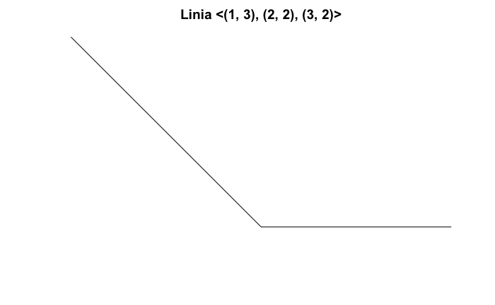

```r
l1 = cbind(c(1,2,3), c(3,2,2)) # koordynaty
sp_line1 = sp::Line(l1)
sp_lines = sp::Lines(list(sp_line1), ID = "a")
sp_final_line = sp::SpatialLines(list(sp_lines))
sp_final_line %>% plot(main = "Linia <(1, 3), (2, 2), (3, 2)>")
```